# Project Business Statistics: E-news Express

## Define Problem Statement and Objectives

## Import all the necessary libraries

```python
# Installing the libraries with the specified version.
# !pip install numpy==1.25.2 pandas==1.5.3 matplotlib==3.7.1 seaborn==0.13.1 scipy==1.11.4 -q --user
# There is an error with the code provided above when run in Google Colab. I'll just import and work with the latest versions of each library.
```

**Note**: *After running the above cell, kindly restart the notebook kernel and run all cells sequentially from the start again.*

```python
# import all necessary libraries
import numpy as np
import pandas as pd
import seaborn as sns
import scipy.stats as stats
import matplotlib.pyplot as plt
```

## Reading the Data into a DataFrame

```python
# mount my google drive
from google.colab import drive
drive.mount('/content/drive')

# read the csv file to a data frame
data=pd.read_csv('/content/drive/MyDrive/Python Foundations - GreatLearning/abtest.csv')
```

## Explore the dataset and extract insights using Exploratory Data Analysis

- Data Overview
  - Viewing the first and last few rows of the dataset
  - Checking the shape of the dataset
  - Getting the statistical summary for the variables
- Check for missing values
- Check for duplicates

```python
# viewing the first few rows of the dataset
data.head(10)
```

|  | user_id | group | landing_page | time_spent_on_the_page | converted | language_preferred |
| --- | --- | --- | --- | --- | --- | --- |
| 0 | 546592 | control | old | 3.48 | no | Spanish |
| 1 | 546468 | treatment | new | 7.13 | yes | English |
| 2 | 546462 | treatment | new | 4.40 | no | Spanish |
| 3 | 546567 | control | old | 3.02 | no | French |
| 4 | 546459 | treatment | new | 4.75 | yes | Spanish |
| 5 | 546558 | control | old | 5.28 | yes | English |
| 6 | 546448 | treatment | new | 5.25 | yes | French |
| 7 | 546581 | control | old | 6.53 | yes | Spanish |
| 8 | 546461 | treatment | new | 10.71 | yes | French |
| 9 | 546548 | control | old | 2.08 | no | English |

```python
# data overview - viewing the first last rows of the dataset
data.tail(10)
```

|  | user_id | group | landing_page | time_spent_on_the_page | converted | language_preferred |
| --- | --- | --- | --- | --- | --- | --- |
| 90 | 546477 | treatment | new | 5.40 | no | French |
| 91 | 546451 | treatment | new | 8.47 | yes | English |
| 92 | 546566 | control | old | 8.35 | no | French |
| 93 | 546474 | treatment | new | 4.94 | no | French |
| 94 | 546550 | control | old | 3.05 | no | English |
| 95 | 546446 | treatment | new | 5.15 | no | Spanish |
| 96 | 546544 | control | old | 6.52 | yes | English |
| 97 | 546472 | treatment | new | 7.07 | yes | Spanish |
| 98 | 546481 | treatment | new | 6.20 | yes | Spanish |
| 99 | 546483 | treatment | new | 5.86 | yes | English |

- We can see that all the control group is getting the old page and all the treatment group is getting the new page. That kind of makes this column redundant.

```python
# checking the shape of the data
print(f'There are {data.shape[0]} rows and {data.shape[1]} columns.')
```

```
There are 100 rows and 6 columns.
```

```python
# getting the statistical summary for the variables
data.describe().T
```

|  | count | mean | std | min | 25% | 50% | 75% | max |
| --- | --- | --- | --- | --- | --- | --- | --- | --- |
| user_id | 100.0 | 546517.0000 | 52.295779 | 546443.00 | 546467.75 | 546492.500 | 546567.2500 | 546592.00 |
| time_spent_on_the_page | 100.0 | 5.3778 | 2.378166 | 0.19 | 3.88 | 5.415 | 7.0225 | 10.71 |

- The mean and percentiles and such for user_id don't actually mean anything. The user_ids are numbers by coincidence and mathematical operations on them will not provide insight.

```python
# check for missing values
data.info()
```

```
<class 'pandas.core.frame.DataFrame'>
RangeIndex: 100 entries, 0 to 99
Data columns (total 6 columns):
 #   Column                  Non-Null Count  Dtype
---  ------                  --------------  -----
 0   user_id                 100 non-null    int64
 1   group                   100 non-null    object
 2   landing_page            100 non-null    object
 3   time_spent_on_the_page  100 non-null    float64
 4   converted               100 non-null    object
 5   language_preferred      100 non-null    object
dtypes: float64(1), int64(1), object(4)
memory usage: 4.8+ KB
```

```python
# check for missing values a second way (not really needed)
data.isnull().sum()
```

```
user_id                   0
group                     0
landing_page              0
time_spent_on_the_page    0
converted                 0
language_preferred        0
dtype: int64
```

- We can see there are no null values, although that does not mean there are no missing data values. Let's check the unique values below.

```python
# checking the data for values like "none" or "n/a"
data['group'].unique()
```

```
array(['control', 'treatment'], dtype=object)
```

```python
# checking the data for values like "none" or "n/a"
data['landing_page'].unique()
```

```
array(['old', 'new'], dtype=object)
```

```python
# checking the data for values like "none" or "n/a"
data['converted'].unique()
```

```
array(['no', 'yes'], dtype=object)
```

```python
# checking the data for values like "none" or "n/a"
data['language_preferred'].unique()
```

```
array(['Spanish', 'English', 'French'], dtype=object)
```

- We can see that there are no entries along the lines of "none" or "N/A". There are no missing values.

```python
# check for duplicates
data['user_id'].nunique()
```

```
100
```

- We can see that none of the user_id values are repeated. For each other category except time_spent_on_the_page, we would expect repeat values. For time_spent_on_the_page, we wouldn't expect repeat values but it wouldn't be a problem if there were a few.

### Univariate Analysis

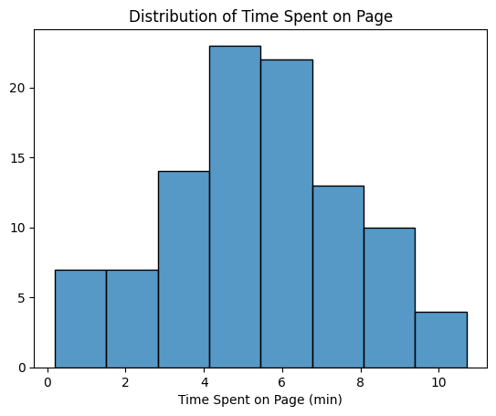

```python
# histograms work well for time-based data
sns.histplot(data=data, x='time_spent_on_the_page')
plt.title('Distribution of Time Spent on Page')
plt.xlabel('Time Spent on Page (min)')
plt.ylabel('') # I don't think showing the word 'Count' is necessary
plt.show()
```

- This information follows an approximately normal distribution

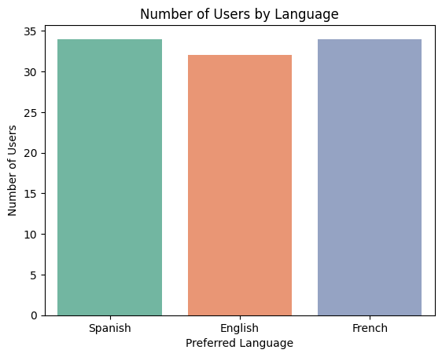

```python
# let's see if there is an even spread of different-language-users
sns.countplot(data=data, x='language_preferred',hue='language_preferred', palette="Set2")
plt.title('Number of Users by Language')
plt.xlabel('Preferred Language')
plt.ylabel('Number of Users')
plt.show()
```

- There are about the same number of users for each language

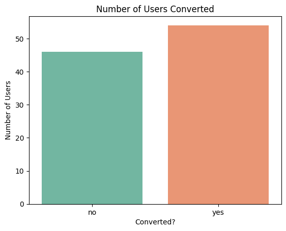

```python
# let's see what proportion of the entire sample group was converted
sns.countplot(data=data, x='converted',hue='converted', palette="Set2")
plt.title('Number of Users Converted')
plt.xlabel('Converted?')
plt.ylabel('Number of Users')
plt.show()
```

- Here we can see slightly more than half the users were converted.

### Bivariate Analysis

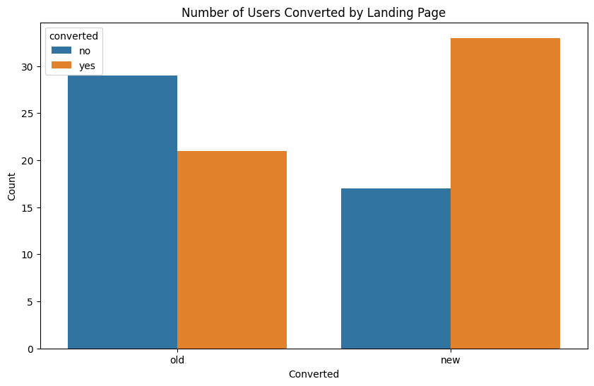

```python
#let's check which landing page got more conversions
plt.figure(figsize=(10, 6))
sns.countplot(data=data, x='landing_page', hue='converted')
plt.title('Number of Users Converted by Landing Page')
plt.xlabel('Converted')
plt.ylabel('Count')
plt.show()
```

- It seems the old landing page is not as effective as the new one

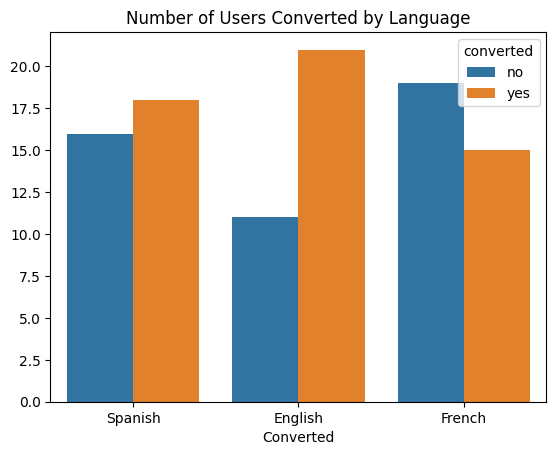

```python
# let's check conversion by language
sns.countplot(data=data, x='language_preferred', hue='converted')
plt.title('Number of Users Converted by Language')
plt.xlabel('Converted')
plt.ylabel('')
plt.show()
```

- It seems the English version of the page worked well while the French version may not have worked well. It might be that the English version of the sight has a higher conversion rate or it might be that we do not have enough data points to tell.

## 1. Do the users spend more time on the new landing page than the existing landing page?

```python
# First, I need to seperate the data based on which landing_page was used
new_data = data[data['landing_page'] == 'new']
old_data = data[data['landing_page'] == 'old']

# This question requires a Two Sample Independant t-test
from scipy.stats import ttest_ind
t_stat, p_val = ttest_ind(new_data['time_spent_on_the_page'], old_data['time_spent_on_the_page'],alternative='greater')
print(f't-statistic: {t_stat}')
print(f'p-value: {p_val}')
```

```
t-statistic: 3.7867702694199856
p-value: 0.0001316123528095005
```

### Perform Visual Analysis

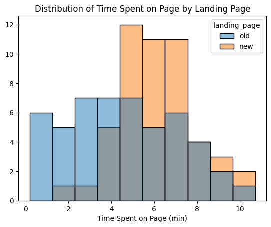

```python
# let's compare the time spent by the landing page
sns.histplot(data=data, x='time_spent_on_the_page',hue='landing_page',bins=10)
plt.title('Distribution of Time Spent on Page by Landing Page')
plt.xlabel('Time Spent on Page (min)')
plt.ylabel('')
plt.show()
```

### Step 1: Define the null and alternate hypotheses

$H_0$: $\mu_{new}$ ≤ $\mu_{old}$

$H_a$: $\mu_{new}$ > $\mu_{old}$

### Step 2: Select Appropriate test

Two-sample independant t-test (mean)

### Step 3: Decide the significance level

$α = 0.05$

### Step 4: Collect and prepare data

```python
# creating subset data frames based on which landing page was used
new_data = data[data['landing_page'] == 'new']
old_data = data[data['landing_page'] == 'old']
```

### Step 5: Calculate the p-value

```python
# import the apporpriate test and calculate p-value
from scipy.stats import ttest_ind
t_stat, p_val = ttest_ind(new_data['time_spent_on_the_page'], old_data['time_spent_on_the_page'],alternative='greater')
print(f't-statistic: {t_stat:.4f}')
print(f'p-value: {p_val:.4f}')
```

```
t-statistic: 3.7868
p-value: 0.0001
```

### Step 6: Compare the p-value with $\alpha$

```python
# compare p-value with significance level
alpha=0.05
print(f'p-value: {p_val:.4f}')
if p_val <= alpha:
    print('Reject the null hypothesis')
else:
    print('Fail to reject the null hypothesis')
```

```
p-value: 0.0001
Reject the null hypothesis
```

### Step 7: Draw inference

When we reject the null hypothesis that does not necessarily mean the alternative hypothesis is true. However, since we are rejecting the null hypothesis, this does support the alternative hypothesis. This means there is support for the alternative hypothesis that more time is spent on the new page than the old page.

## 2. Is the conversion rate (the proportion of users who visit the landing page and get converted) for the new page greater than the conversion rate for the old page?

### Perform Visual Analysis

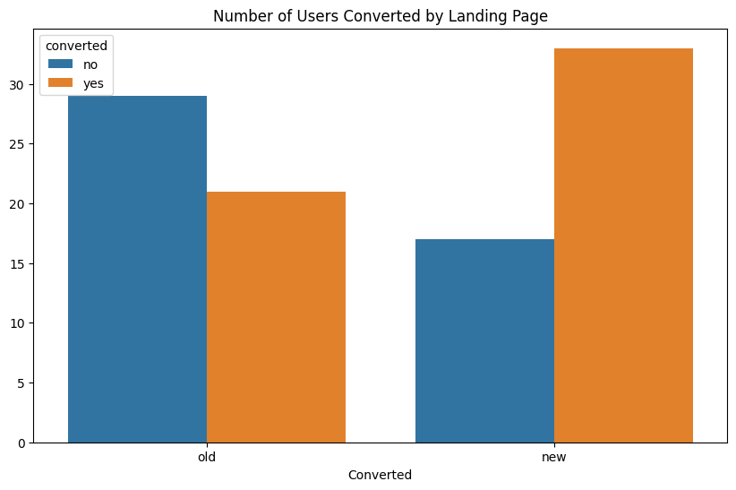

```python
# I already had this in bivariate analysis but I can put it here too
plt.figure(figsize=(10, 6))
sns.countplot(data=data, x='landing_page', hue='converted')
plt.title('Number of Users Converted by Landing Page')
plt.xlabel('Converted')
plt.ylabel('')
plt.show()
```

### Step 1: Define the null and alternate hypotheses

$H_0$: $p_{new}$ ≤ $p_{old}$

$H_a$: $p_{new}$ > $p_{old}$

### Step 2: Select Appropriate Test

Two-sample z-test (proportion)

### Step 3: Decide the significance level

$α = 0.05$

### Step 4: Collect and prepare data

```python
# technically already done
new_data = data[data['landing_page'] == 'new']
old_data = data[data['landing_page'] == 'old']

# Count 'yes' values for the 'converted' column in each dataframe
new_converted_count = (new_data['converted'] == 'yes').sum()
old_converted_count = (old_data['converted'] == 'yes').sum()
```

### Step 5: Calculate the p-value

```python
# import the apporpriate test and calculate p-value
from statsmodels.stats.proportion import proportions_ztest
z_stat, p_val = proportions_ztest([new_converted_count, old_converted_count], [len(new_data), len(old_data)], alternative='larger')
print(f'z-statistic: {z_stat:.4f}')
print(f'p-value: {p_val:.4f}')
```

```
z-statistic: 2.4077
p-value: 0.0080
```

### Step 6: Compare the p-value with $\alpha$

```python
# compare p-value with level of significance
alpha=0.05
print(f'p-value: {p_val:.4f}')
if p_val <= alpha:
    print('Reject the null hypothesis')
else:
    print('Fail to reject the null hypothesis')
```

```
p-value: 0.0080
Reject the null hypothesis
```

### Step 7: Draw inference

We reject the null hypothesis. This means the alternative hypothesis supported. We can say the hypothesis that the new site converts more users is supported.

## 3. Is the conversion and preferred language are independent or related?

### Perform Visual Analysis

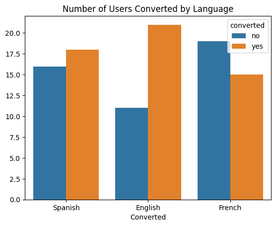

```python
# I also had this under bivariate analysis but I can redo it here as well
sns.countplot(data=data, x='language_preferred', hue='converted')
plt.title('Number of Users Converted by Language')
plt.xlabel('Converted')
plt.ylabel('')
plt.show()
```

### Step 1: Define the null and alternate hypotheses

$H_0$: Preferred Language and Conversion **ARE** independent.

$H_a$: Preferred Language and Conversion **ARE NOT** independent (there is a relationship).

### Step 2: Select Appropriate Test

Chi-Square Test of Independence (frequencies)

### Step 3: Decide the significance level

$α = 0.05$

### Step 4: Collect and prepare data

```python
# import the apporpriate test
from scipy.stats import chi2_contingency

# build table to use in test
contingency_table = pd.crosstab(data['language_preferred'], data['converted'])
print(contingency_table) #just double checking the contingency table is good
```

```
converted           no  yes
language_preferred
English             11   21
French              19   15
Spanish             16   18
```

### Step 5: Calculate the p-value

```python
# import the apporpriate test and calculate p-value
chi2_stat, p_val, dof, expected = chi2_contingency(contingency_table)
print(f"Chi-square statistic: {chi2_stat:.4f}")
print(f"P-value: {p_val:.4f}")
```

```
Chi-square statistic: 3.0930
P-value: 0.2130
```

### Step 6: Compare the p-value with $\alpha$

```python
# compare p-value with level of significance
alpha=0.05
print(f'p-value: {p_val:.4f}')
if p_val <= alpha:
    print('Reject the null hypothesis')
else:
    print('Fail to reject the null hypothesis')
```

```
p-value: 0.2130
Fail to reject the null hypothesis
```

### Step 7: Draw inference

We failed to reject the null hypothesis. This means, according to the data available, that preferred language and conversion rate are not related; they are independent.

## 4. Is the time spent on the new page same for the different language users?

### Perform Visual Analysis

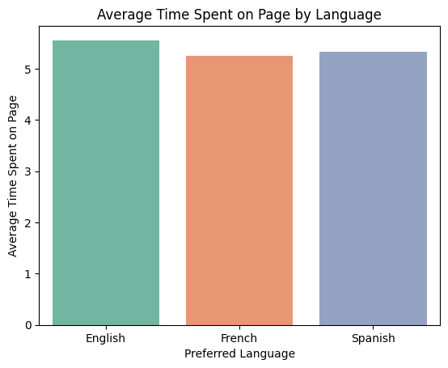

```python
# visualize average time spent by preferred language
sns.barplot(data=data.groupby('language_preferred')['time_spent_on_the_page'].mean().reset_index(), x='language_preferred', y='time_spent_on_the_page', hue='language_preferred', palette="Set2")
plt.title('Average Time Spent on Page by Language')
plt.xlabel('Preferred Language')
plt.ylabel('Average Time Spent on Page')
plt.show()
```

### Step 1: Define the null and alternate hypotheses

$H_0$: $\mu_{Eng} = \mu_{Fre} = \mu_{Spa}$

$H_a$: at least one of these means is not the same

### Step 2: Select Appropriate Test

ANOVA Test (means)

### Step 3: Decide the significance level

$\alpha = 0.05$

### Step 4: Collect and prepare data

```python
# the Shapiro-Wilk's test deterimines if the data is a normal distribution
from scipy.stats import shapiro
new_user_data=data[data['landing_page']=='new']
english_timespent = new_user_data[new_user_data['language_preferred'] == 'English']['time_spent_on_the_page']
french_timespent = new_user_data[new_user_data['language_preferred'] == 'French']['time_spent_on_the_page']
spanish_timespent = new_user_data[new_user_data['language_preferred'] == 'Spanish']['time_spent_on_the_page']

print(f"The mean of the English timespent is {english_timespent.mean():.4f}")
print(f"The mean of the French timespent is {french_timespent.mean():.4f}")
print(f"The mean of the Spanish timespent is {spanish_timespent.mean():.4f}\n")


english_statistic, english_p_val = shapiro(english_timespent)
print(f"Shapiro-Wilk Test for Normality (English):")
print(f"English Test Statistic: {english_statistic:.4f}")
print(f"English P-value: {english_p_val:.4f}\n")

french_statistic, french_p_val = shapiro(french_timespent)
print(f"Shapiro-Wilk Test for Normality (French):")
print(f"French Test Statistic: {french_statistic:.4f}")
print(f"French P-value: {french_p_val:.4f}\n")

spanish_statistic, spanish_p_val = shapiro(spanish_timespent)
print(f"Shapiro-Wilk Test for Normality (Spanish):")
print(f"Spanish Test Statistic: {spanish_statistic:.4f}")
print(f"Spanish P-value: {spanish_p_val:.4f}")
```

```
The mean of the English timespent is 6.6638
The mean of the French timespent is 6.1965
The mean of the Spanish timespent is 5.8353

Shapiro-Wilk Test for Normality (English):
English Test Statistic: 0.9731
English P-value: 0.8863

Shapiro-Wilk Test for Normality (French):
French Test Statistic: 0.9403
French P-value: 0.3214

Shapiro-Wilk Test for Normality (Spanish):
Spanish Test Statistic: 0.9073
Spanish P-value: 0.0901
```

We can see that the p-values indicate that time_spent_on_the_page by language_preferred are all normally distributed. This proves our first assumption, Normality.

```python
# the Levene test determines the homogeneity of variance
from scipy.stats import levene
levene_statistic, levene_p_val = levene(english_timespent, french_timespent, spanish_timespent)
print("Levene Test for Homogeneity of Variance:")
print(f"Levene Test Statistic: {levene_statistic:.4f}")
print(f"Levene P-value: {levene_p_val:.4f}")
```

```
Levene Test for Homogeneity of Variance:
Levene Test Statistic: 0.7736
Levene P-value: 0.4671
```

We can see from the Levene test that the p-value is not less than the signifcance level so this proves our second assumption for ANOVA tests, Homogeneity of Variance. We can now perform an ANOVA test.

### Step 5: Calculate the p-value

```python
# import the apporpriate test and calculate p-value
from scipy.stats import f_oneway
f_test_stat, f_test_p_val = f_oneway(english_timespent, french_timespent, spanish_timespent)
print("ANOVA Test Comparing two or more means:")
print(f"F-test statistic: {f_test_stat:.4f}")
print(f"F-test p-value: {f_test_p_val:.4f}")
```

```
ANOVA Test Comparing two or more means:
F-test statistic: 0.8544
F-test p-value: 0.4320
```

### Step 6: Compare the p-value with $\alpha$

```python
# compare the p-value to the level of significance
alpha=0.05
print(f'p-value: {f_test_p_val:.4f}')
if f_test_p_val <= alpha:
    print('Reject the null hypothesis')
else:
    print('Fail to reject the null hypothesis')
```

```
p-value: 0.4320
Fail to reject the null hypothesis
```

### Step 7: Draw inference

We failed to reject the null hypothesis. That means the average time spend looking at the landing page was not statistically significantly different for users of different preferred languages.

## Conclusion and Business Recommendations

It seems obvious to me, after looking at the data, that the new website is statistically significantly better than the old website and sees a noticably better conversion rate on average. I recommend they go with the new website.

```python
%shell jupyter nbconvert --to html '/content/drive/MyDrive/Python Foundations - GreatLearning/ENews_Express_Learner_Notebook_Full_Code.ipynb'
```

```
[NbConvertApp] Converting notebook /content/drive/MyDrive/Python Foundations - GreatLearning/ENews_Express_Learner_Notebook_Full_Code.ipynb to html
[NbConvertApp] Writing 692561 bytes to /content/drive/MyDrive/Python Foundations - GreatLearning/ENews_Express_Learner_Notebook_Full_Code.html
```